# Cardinal

2017-02-10

## Contents

[Cardinal](https://bioconductor.org/packages/release/bioc/html/Cardinal.html) is a package for R designed to be used for the analsis of mass spectrometry imaging data, I'll demonstrate:

- Reading in IMZML data.
- Peakpicking.
- Plotting Spectra.
- Plotting Masses.
- Multivariate Methods.

## Reading Data

Reading IMZML data is trivial. Cardinal can also read Analyze 7.5 format imaging data if needed.

```r
d.name = "example"
d.fold = "data"
data   = readImzML(d.name, d.fold)
```

All the relevant information about the data can be obtained through the functions `mz`, `coord`, `spectra`, `features`, `pixels`, and some overwritten base functions such as `dims`, `nrow`, and `ncol`, for example:

```r
dim(data)
```

```
## Features   Pixels
##     1001    51783
```

## Peakpicking and other Preprocessing

Can be performed using various provided functions, including normalisation (`normalize`), smoothing (`smoothSignal`), baseline reduction (`reduceBaseline`), peak picking (`peakPick`), and peak alignment (`peakAlign`).

Cardinal also includes some useful functions for other common preprocessing operations such as resamping/ binning (`reduceDimension`) and filtering rare peaks (`peakFilter`).

## Plotting Individual Spectra

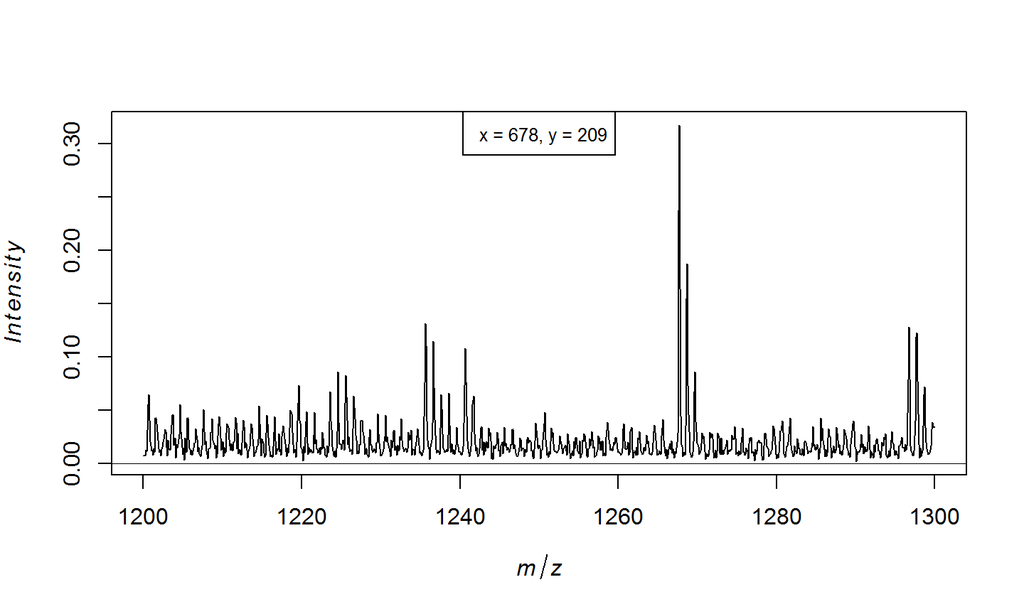

```r
plot(data, coord = list(x = 678, y = 209))
```

## Plotting Mean Spectra

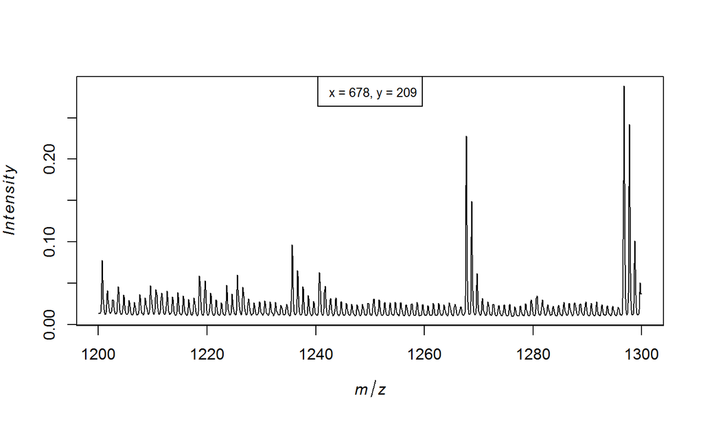

```r
plot(data, coord = list(x = 678, y = 209), plusminus = 5)
```

## Plotting Multiple Spectra

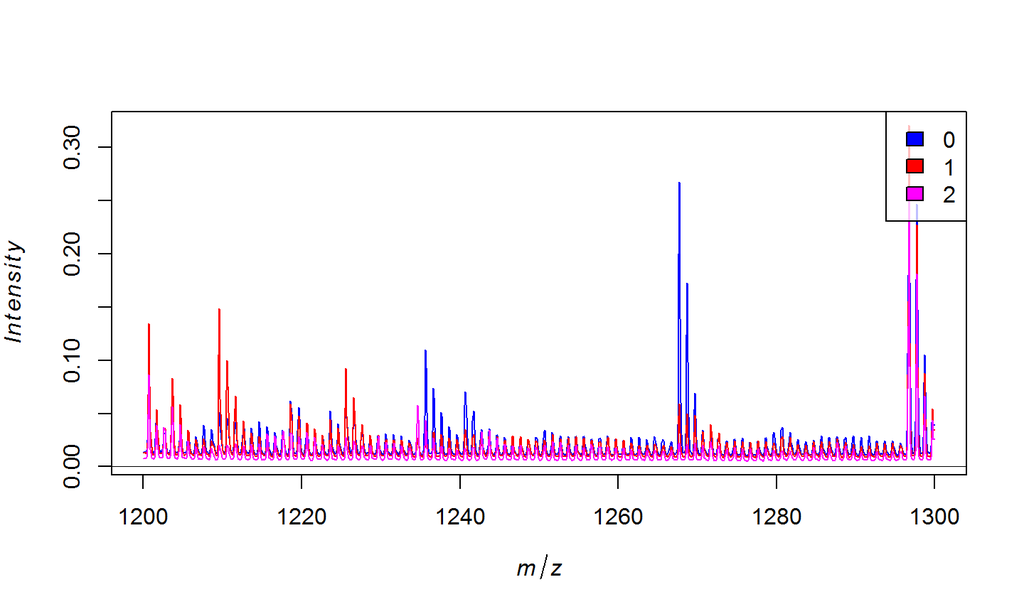

```r
plot(data, pixel=spec, pixel.groups = group,
     superpose = TRUE, key = TRUE, col = c("blue", "red", "magenta"))
```

## Similarly, Masses can be plotted spatially.

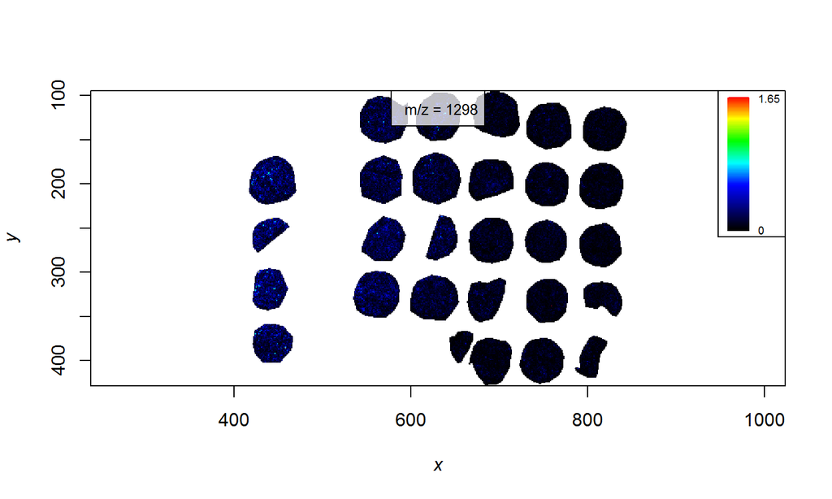

```r
image(data, mz = 1298, plusminus=0.3)
```

## Multivariate Methods

Such as PCA, PLS, O-PLS, spatial k-means and some others are all provided as high-level user friendly functions as well. These are slow however, and so it is advisable to perform some data reduction prior to using them so that iteration is faster.

## Colophon

These slides were written in [Rmarkdown](http://rmarkdown.rstudio.com/) inside [RStudio](https://www.rstudio.com/products/rstudio/). Markdown is a simple formatting syntax for authoring HTML, PDF, and MS Word documents. [knitr](http://yihui.name/knitr/) and [pandoc](http://pandoc.org/) converted the raw Rmarkdown to html. The complete source is available from [github](https://github.com/Armadilloa16/cardinal). The wording for this colophon was inspired by [hadley's book](http://r-pkgs.had.co.nz/), which is a useful resource I would reccomend to anyone aspiring to learn to write packages for R.